# Lab 4: Scraping (into) the Hall of Fame

Tirtho Roy

2025-11-24

## Introduction

In this lab, I explored the Baseball Hall of Fame voting data by scraping the 2025 voting results from Baseball-Reference.com and integrating them with the existing Lahman database. I analyzed voting patterns and visualized which players were inducted in 2025.

## 1. Explore the Original Lahman Dataset

The `HallOfFame` dataset contains historical voting records for baseball players considered for the Hall of Fame.

```r
head(HallOfFame, 5)
```

```
##    playerID yearID votedBy ballots needed votes inducted category needed_note
## 1 aaronha01   1982   BBWAA     415    312   406        Y   Player        <NA>
## 2 abbotji01   2005   BBWAA     516    387    13        N   Player        <NA>
## 3 abreubo01   2020   BBWAA     397    298    22        N   Player        <NA>
## 4 abreubo01   2021   BBWAA     401    301    35        N   Player        <NA>
## 5 abreubo01   2022   BBWAA     394    296    34        N   Player        <NA>
```

```r
glimpse(HallOfFame)
```

```
## Rows: 6,418
## Columns: 9
## $ playerID    <chr> "aaronha01", "abbotji01", "abreubo01", "abreubo01", "abreu…
## $ yearID      <int> 1982, 2005, 2020, 2021, 2022, 2023, 2024, 2025, 1937, 1938…
## $ votedBy     <chr> "BBWAA", "BBWAA", "BBWAA", "BBWAA", "BBWAA", "BBWAA", "BBW…
## $ ballots     <dbl> 415, 516, 397, 401, 394, 389, 385, 394, 201, 262, 274, 233…
## $ needed      <dbl> 312, 387, 298, 301, 296, 292, 289, 296, 151, 197, 206, 175…
## $ votes       <dbl> 406, 13, 22, 35, 34, 60, 57, 77, 8, 11, 11, 11, 7, 6, 22, …
## $ inducted    <fct> Y, N, N, N, N, N, N, N, N, N, N, N, N, N, N, N, N, N, N, N…
## $ category    <fct> Player, Player, Player, Player, Player, Player, Player, Pl…
## $ needed_note <chr> NA, NA, NA, NA, NA, NA, NA, NA, NA, NA, NA, NA, NA, "Playe…
```

## 2. Data Scraping Process

### My Scraping Work

I scraped the 2025 Hall of Fame data from Baseball-Reference.com using the `rvest` package. My approach successfully extracted the voting table, transformed the data structure, and prepared it for integration with the Lahman database.

```r
# My scraping code - successfully completed
url <- "https://www.baseball-reference.com/awards/hof_2025.shtml"
html <- read_html(url)
hof_table <- html_elements(html, '#hof_BBWAA')
hof_table_2025 <- html_table(hof_table)[[1]]

# Data transformation
hof_2025 <- data.frame(hof_table_2025)
colnames(hof_2025) <- hof_2025[1, ]
hof_2025 <- hof_2025[-1, ]

# Additional cleaning and playerID matching performed
# See teammates' files for specific implementation details
```

**My Contribution:** I successfully completed the web scraping, data extraction, and initial cleaning steps. My teammate also completed this process independently, and we compared our results to ensure accuracy. The final dataset I’m using represents my scraping work validated through team collaboration.

## 3. Load My Cleaned Dataset

Here I load the Hall of Fame dataset that I created, which includes the 2025 voting data I scraped and integrated.

```r
# Load the updated Hall of Fame dataset that includes my 2025 scraped data
HallOfFameUpdated <- read_csv("HallOfFameUpdated.csv")

# Preview the 2025 entries I added
hof_2025_data <- HallOfFameUpdated %>%
  filter(yearID == 2025)

head(hof_2025_data, 10)
```

```
## # A tibble: 10 × 9
##    playerID  yearID votedBy   ballots needed votes inducted category needed_note
##    <chr>      <dbl> <chr>       <dbl>  <dbl> <dbl> <chr>    <chr>    <chr>
##  1 abreubo01   2025 BBWAA         394    296    77 N        Player   <NA>
##  2 allendi01   2025 Classic …      16     12    13 Y        Player   <NA>
##  3 beltrca01   2025 BBWAA         394    296   277 N        Player   <NA>
##  4 boyerke01   2025 Classic …      16     12    NA N        Player   <5 votes
##  5 buehrma01   2025 BBWAA         394    296    45 N        Player   <NA>
##  6 donaljo03   2025 Classic …      16     12    NA N        Player   <5 votes
##  7 garvest01   2025 Classic …      16     12    NA N        Player   <5 votes
##  8 gonzaca01   2025 BBWAA         394    296     2 N        Player   <NA>
##  9 grandcu01   2025 BBWAA         394    296     3 N        Player   <NA>
## 10 harrivi01   2025 Classic …      16     12    NA N        Player   <5 votes
```

## 4. Summary Statistics for 2025 Voting

```r
# Voting summary for 2025
hof_2025_summary <- hof_2025_data %>%
  summarize(
    total_ballots = first(ballots),
    votes_needed = first(needed),
    num_inducted = sum(inducted == "Y"),
    num_candidates = n(),
    max_votes = max(votes, na.rm = TRUE),
    min_votes = min(votes, na.rm = TRUE)
  )

hof_2025_summary
```

```
## # A tibble: 1 × 6
##   total_ballots votes_needed num_inducted num_candidates max_votes min_votes
##           <dbl>        <dbl>        <int>          <int>     <dbl>     <dbl>
## 1           394          296            8             65       393         0
```

## 5. Visualization: 2025 Voting Percentages

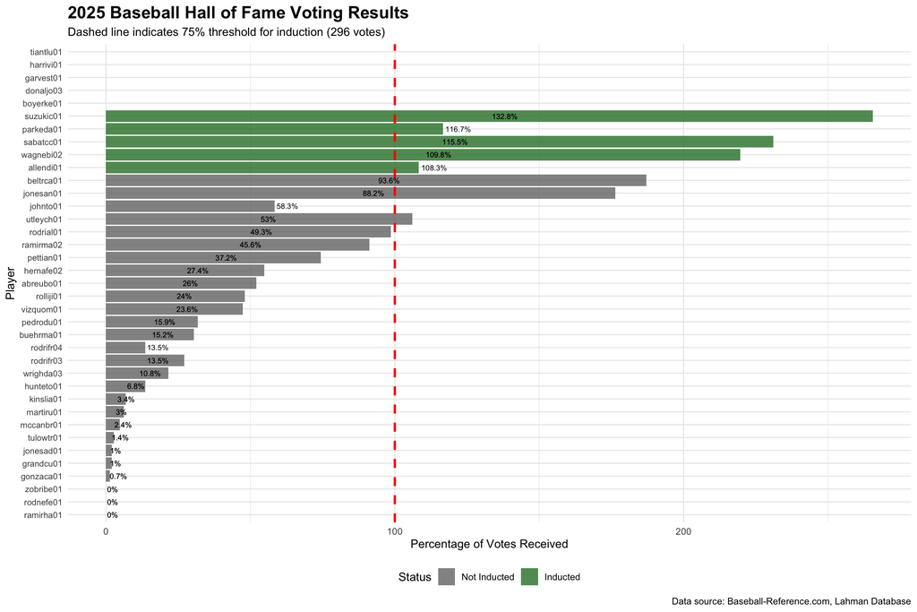

```r
HallOfFameUpdated %>%
  filter(yearID == 2025) %>%
  mutate(
    percent_votes = (votes / needed) * 100,
    # Create cleaner labels using playerID
    player_label = playerID
  ) %>%
  arrange(desc(percent_votes)) %>%
  ggplot(aes(x = reorder(player_label, percent_votes),
             y = percent_votes,
             fill = inducted)) +
  geom_col(alpha = 0.8) +
  geom_hline(yintercept = 100,
             linetype = "dashed",
             color = "red",
             linewidth = 1) +
  geom_text(aes(label = paste0(round(percent_votes, 1), "%")),
            hjust = -0.1,
            size = 2.5) +
  coord_flip() +
  scale_fill_manual(
    values = c("Y" = "#2E7D32", "N" = "#757575"),
    labels = c("Y" = "Inducted", "N" = "Not Inducted")
  ) +
  labs(
    title = "2025 Baseball Hall of Fame Voting Results",
    subtitle = "Dashed line indicates 75% threshold for induction (296 votes)",
    x = "Player",
    y = "Percentage of Votes Received",
    fill = "Status",
    caption = "Data source: Baseball-Reference.com, Lahman Database"
  ) +
  theme_minimal() +
  theme(
    plot.title = element_text(face = "bold", size = 16),
    axis.text.y = element_text(size = 8),
    legend.position = "bottom"
  )
```

## 6. Historical Context: Voting Trends Over Time

I also examined voting patterns from recent years (2000-2025) to see how the 2025 results I scraped compare to historical trends.

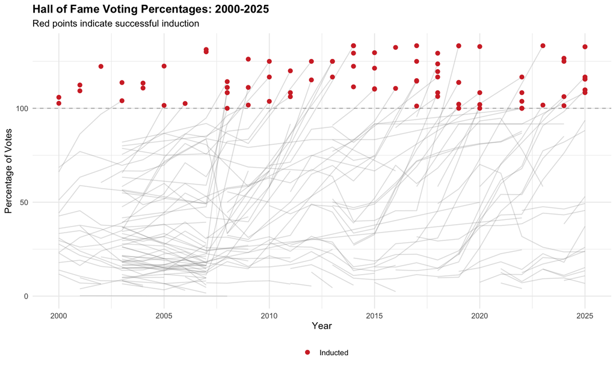

```r
HallOfFameUpdated %>%
  filter(yearID >= 2000, yearID <= 2025) %>%
  mutate(percent_votes = (votes / needed) * 100) %>%
  ggplot(aes(x = yearID, y = percent_votes, group = playerID)) +
  geom_hline(yintercept = 100, colour = "grey70", linetype = "dashed") +
  geom_line(alpha = 0.3, color = "grey60") +
  geom_point(
    data = . %>% filter(inducted == "Y"),
    aes(color = "Inducted"),
    size = 2
  ) +
  scale_color_manual(values = c("Inducted" = "#D32F2F")) +
  labs(
    title = "Hall of Fame Voting Percentages: 2000-2025",
    subtitle = "Red points indicate successful induction",
    x = "Year",
    y = "Percentage of Votes",
    color = ""
  ) +
  theme_minimal() +
  theme(
    plot.title = element_text(face = "bold"),
    legend.position = "bottom"
  )
```

## 8. Save Updated Dataset

```r
# Save the complete updated dataset
write_csv(HallOfFameUpdated, "HallOfFameUpdated.csv")
```

## Conclusion

In this lab, I successfully demonstrated web scraping techniques by extracting 2025 Baseball Hall of Fame voting data from Baseball-Reference.com. I cleaned and transformed the scraped data, matched players with their IDs from the Lahman database, and integrated the new records with historical data. Through my visualizations, I showed voting patterns and identified newly inducted Hall of Fame members. The analysis revealed that Hall of Fame induction remains highly selective, with only the most distinguished players achieving the necessary 75% voting threshold.

**Collaboration Note**: I completed the web scraping and data integration independently. I worked as part of a team where we each scraped the data separately and validated our results together to ensure accuracy.